# MCMVR Example

Aaron J. Molstad (amolstad@ufl.edu)

7/18/2019

In this document, we provide a short tutorial on how to use the $\texttt{MCMVR}$ R package. We download this package from GitHub.

```r
install.packages("devtools")
library(devtools)
devtools::install_github("ajmolstad/MCMVR")
library(MCMVR)
```

First, we generate data from the “errors-in-variables” data generating model described in Section 3.1 of the article.

```r
set.seed(1)
p <- 50
q <- 10
n <- 100

beta <- matrix(rnorm(p * q) * sample(c(0, 1), p * q, prob = c(0.9, 0.1), replace = TRUE),
    nrow = p, ncol = q)

Z <- matrix(rnorm(n * p), nrow = n, ncol = p)
Y <- tcrossprod(Z, t(beta)) + matrix(rnorm(n * q, sd = 1), nrow = n)
X <- Z + matrix(rnorm(n * p, sd = sqrt(0.5)), nrow = n)

Znew <- matrix(rnorm(n * p), nrow = n, ncol = p)
Xnew <- Znew + matrix(rnorm(n * p, sd = sqrt(0.5)), nrow = n)
Ynew <- tcrossprod(Znew, t(beta)) + matrix(rnorm(n * q, sd = 1), nrow = n)
```

We fit the model using the cross-validation function. There are a number of key arguments: the first is $\texttt{tau.vec}$, where a user must specify a vector of candidate tuning parameters $\tau$ over which to fit the model:
$$\arg \min_{\beta} {\rm tr}\left\{n^{-1}(Y - X\beta) (\beta'\beta + \tau I_q)^{-1}(Y - X\beta)' \right\} + \frac{\lambda}{\tau}{\rm Pen}(\beta).$$
Another important argument is $\texttt{nfolds}$. If set to NULL, cross-validation is not performed, the model is fit to the complete data without cross-validation. Finally, a user must also decide which penalty to use. The current options are $\texttt{penalty="L1"}$ and $\texttt{penalty="NN"}$ which set ${\rm Pen}(\beta) = \sum_{j,k}|\beta_{j,k}|$ and ${\rm Pen}(\beta) = \sum_{j=1}^{\min (p,q)} \varphi_j(\beta)$, respectively, where $\varphi_j(\beta)$ is the $j$th largest singular value of $\beta$. Note that one only needs to input the number of candidate $\lambda$, $\texttt{nlambda}$, and the ratio of max to min lambda $\texttt{delta}$.

```r
# --------------------------------------------------- Perform 5-fold CV for
# a grid of tuning parameters
# ---------------------------------------------------
tau.vec <- 10^seq(3, 0, by = -0.5)
fit <- MCMVR.cv(X = X, Y = Y, tau.vec = tau.vec, nlambda = 50, nfolds = 5, delta = 0.01,
    tol = 1e-08, quiet = TRUE, inner.quiet = TRUE, penalty = "L1")
str(fit)
```

```
## List of 10
##  $ beta        : num [1:3500, 1:50] 0 0 0 0 0 0 0 0 0 0 ...
##  $ sparsity.mat: num [1:50, 1:7] 0 1 2 2 2 2 5 6 8 8 ...
##  $ err.pred    : num [1:50, 1:7, 1:5] 6.66 6.58 6.51 6.45 6.4 ...
##  $ err.wpred   : num [1:50, 1:7, 1:5] 0.969 0.964 0.959 0.955 0.951 ...
##  $ Y.offset    : num [1:10] 0.2821 -0.1201 0.0626 -0.1167 -0.2071 ...
##  $ X.offset    : num [1:50] -0.03591 0.00857 -0.18562 -0.15828 -0.01975 ...
##  $ lambda.vec  : num [1:50] 6.12 5.57 5.07 4.62 4.2 ...
##  $ tau.vec     : num [1:7] 1000 316.2 100 31.6 10 ...
##  $ tau.min     : num 3.16
##  $ lam.min     : num 0.44
##  - attr(*, "class")= chr "MCMVR"
```

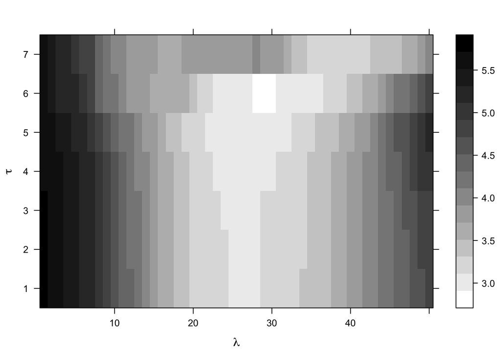

```r
# --------------------------------------------------- visualize CV error
# ---------------------------------------------------
library(lattice)
levelplot(apply(fit$err.pred, c(1, 2), mean), col.regions = grey(100:0/100),
    xlab = expression(lambda), ylab = expression(tau), aspect = "fill")
```

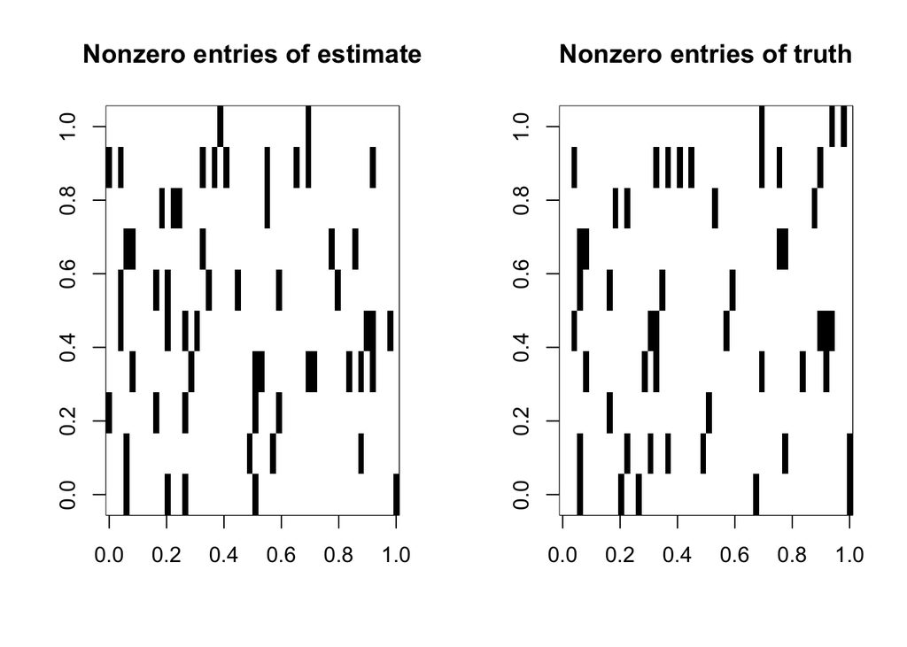

```r
# --------------------------------------------------- get coefs from model
# which minimized CV error
# ---------------------------------------------------
betas <- MCMVR.coef(fit)$beta

par(mfrow = c(1, 2))
image(betas != 0, col = grey(100:0/100), main = paste("Nonzero entries of estimate"))
image(beta != 0, col = grey(100:0/100), main = paste("Nonzero entries of truth"))
```

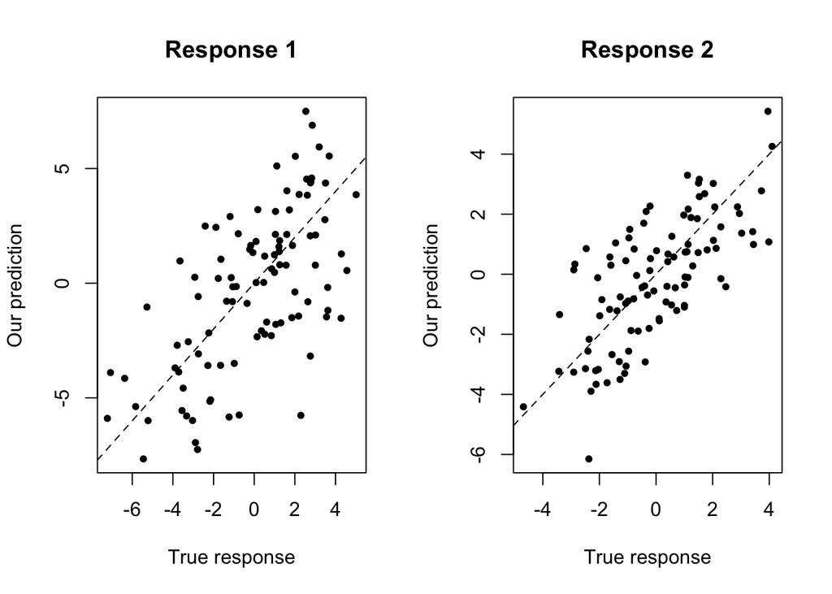

```r
# ------------------------------------------------- make predictions for
# Xnew ------------------------------------------------
preds <- MCMVR.predict(Xnew, fit)

par(mfrow = c(1, 2))
plot(preds$preds[, 1], Ynew[, 1], pch = 20, main = "Response 1", ylab = "Our prediction",
    xlab = "True response")
abline(0, 1, lty = 2)
plot(preds$preds[, 2], Ynew[, 2], pch = 20, main = "Response 2", ylab = "Our prediction",
    xlab = "True response")
abline(0, 1, lty = 2)
```

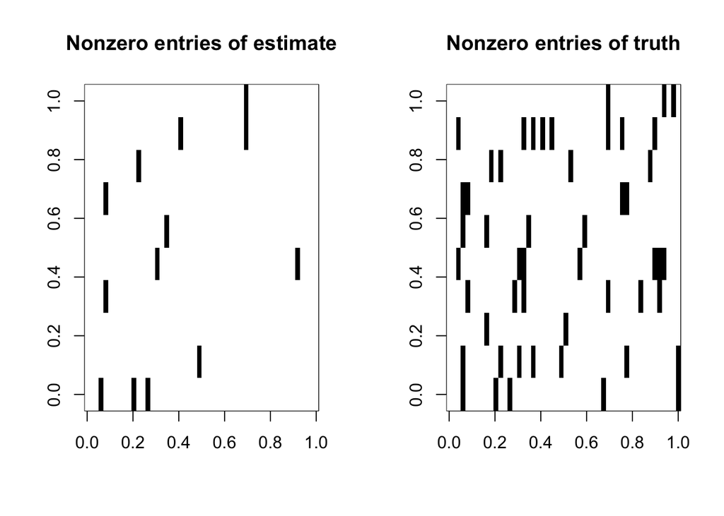

```r
# --------------------------------------------------- get coefs from model
# with seperate tuning parameter
# ---------------------------------------------------
betas <- MCMVR.coef(fit, tau = fit$tau.vec[1], lambda = fit$lambda.vec[12])$beta

par(mfrow = c(1, 2))
image(betas != 0, col = grey(100:0/100), main = paste("Nonzero entries of estimate"))
image(beta != 0, col = grey(100:0/100), main = paste("Nonzero entries of truth"))
```

```r
# --------------------------------------------------- Perform 5-fold CV for
# a grid of tuning parameters
# ---------------------------------------------------
tau.vec <- 10^seq(3, 0, by = -0.5)
fit <- MCMVR.cv(X = X, Y = Y, tau.vec = tau.vec, nlambda = 20, nfolds = 5, delta = 0.01,
    tol = 1e-10, quiet = FALSE, inner.quiet = TRUE, penalty = "NN")
```

```
## tau = 1000 : lambda = 9.989233 : nuclear norm = 0
## tau = 1000 : lambda = 7.83915 : nuclear norm = 0.4969919
## tau = 1000 : lambda = 6.151851 : nuclear norm = 1.491432
## tau = 1000 : lambda = 4.827727 : nuclear norm = 2.895799
## tau = 1000 : lambda = 3.788607 : nuclear norm = 4.394054
## tau = 1000 : lambda = 2.973147 : nuclear norm = 6.037959
## tau = 1000 : lambda = 2.333207 : nuclear norm = 7.633972
## tau = 1000 : lambda = 1.831007 : nuclear norm = 9.085348
## tau = 1000 : lambda = 1.436901 : nuclear norm = 10.42884
## tau = 1000 : lambda = 1.127623 : nuclear norm = 11.61476
## tau = 1000 : lambda = 0.884913 : nuclear norm = 12.65818
## tau = 1000 : lambda = 0.6944443 : nuclear norm = 13.56972
## tau = 1000 : lambda = 0.5449721 : nuclear norm = 14.36509
## tau = 1000 : lambda = 0.4276723 : nuclear norm = 15.04664
## tau = 1000 : lambda = 0.3356201 : nuclear norm = 15.62766
## tau = 1000 : lambda = 0.2633812 : nuclear norm = 16.11633
## tau = 1000 : lambda = 0.206691 : nuclear norm = 16.5221
## tau = 1000 : lambda = 0.1622028 : nuclear norm = 16.85975
## tau = 1000 : lambda = 0.1272903 : nuclear norm = 17.13038
## tau = 1000 : lambda = 0.09989233 : nuclear norm = 17.35113
## tau = 316.2278 : lambda = 9.989233 : nuclear norm = 0
## tau = 316.2278 : lambda = 7.83915 : nuclear norm = 0.5005064
## tau = 316.2278 : lambda = 6.151851 : nuclear norm = 1.498667
## tau = 316.2278 : lambda = 4.827727 : nuclear norm = 2.905169
## tau = 316.2278 : lambda = 3.788607 : nuclear norm = 4.403946
## tau = 316.2278 : lambda = 2.973147 : nuclear norm = 6.048851
## tau = 316.2278 : lambda = 2.333207 : nuclear norm = 7.645307
## tau = 316.2278 : lambda = 1.831007 : nuclear norm = 9.097865
## tau = 316.2278 : lambda = 1.436901 : nuclear norm = 10.44415
## tau = 316.2278 : lambda = 1.127623 : nuclear norm = 11.6329
## tau = 316.2278 : lambda = 0.884913 : nuclear norm = 12.67971
## tau = 316.2278 : lambda = 0.6944443 : nuclear norm = 13.59708
## tau = 316.2278 : lambda = 0.5449721 : nuclear norm = 14.39732
## tau = 316.2278 : lambda = 0.4276723 : nuclear norm = 15.08625
## tau = 316.2278 : lambda = 0.3356201 : nuclear norm = 15.67322
## tau = 316.2278 : lambda = 0.2633812 : nuclear norm = 16.16929
## tau = 316.2278 : lambda = 0.206691 : nuclear norm = 16.58112
## tau = 316.2278 : lambda = 0.1622028 : nuclear norm = 16.92016
## tau = 316.2278 : lambda = 0.1272903 : nuclear norm = 17.19877
## tau = 316.2278 : lambda = 0.09989233 : nuclear norm = 17.42263
```

[output cut: 90 more lines]

```
## tau = 1 : lambda = 0.884913 : nuclear norm = 12.118
## tau = 1 : lambda = 0.6944443 : nuclear norm = 13.14494
## tau = 1 : lambda = 0.5449721 : nuclear norm = 14.17462
## tau = 1 : lambda = 0.4276723 : nuclear norm = 15.21416
## tau = 1 : lambda = 0.3356201 : nuclear norm = 16.26758
## tau = 1 : lambda = 0.2633812 : nuclear norm = 17.33527
## tau = 1 : lambda = 0.206691 : nuclear norm = 18.41499
## tau = 1 : lambda = 0.1622028 : nuclear norm = 19.50372
## tau = 1 : lambda = 0.1272903 : nuclear norm = 20.59899
## tau = 1 : lambda = 0.09989233 : nuclear norm = 21.69823
## Through CV fold 1
## Through CV fold 2
## Through CV fold 3
## Through CV fold 4
## Through CV fold 5
```

```r
str(fit)
```

```
## List of 10
##  $ beta        : num [1:3500, 1:20] 0 0 0 0 0 0 0 0 0 0 ...
##  $ sparsity.mat: num [1:20, 1:7] 0 500 500 500 500 500 500 500 500 500 ...
##  $ err.pred    : num [1:20, 1:7, 1:5] 6.61 6.4 6.07 5.58 5.11 ...
##  $ err.wpred   : num [1:20, 1:7, 1:5] 0.979 0.954 0.906 0.836 0.775 ...
##  $ Y.offset    : num [1:10] 0.2821 -0.1201 0.0626 -0.1167 -0.2071 ...
##  $ X.offset    : num [1:50] -0.03591 0.00857 -0.18562 -0.15828 -0.01975 ...
##  $ lambda.vec  : num [1:20] 9.99 7.84 6.15 4.83 3.79 ...
##  $ tau.vec     : num [1:7] 1000 316.2 100 31.6 10 ...
##  $ tau.min     : num 1000
##  $ lam.min     : num 1.44
##  - attr(*, "class")= chr "MCMVR"
```

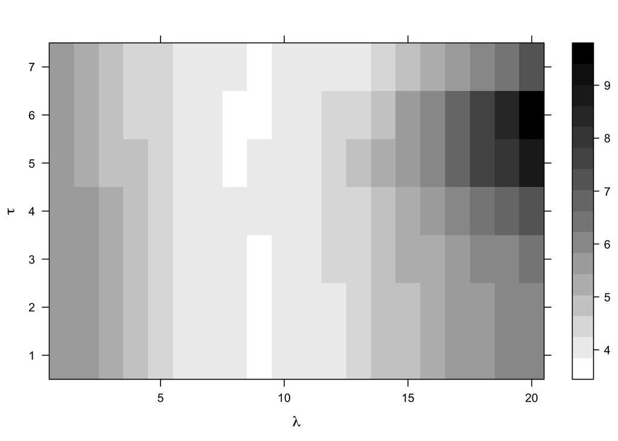

```r
levelplot(apply(fit$err.pred, c(1, 2), mean), col.regions = grey(100:0/100),
    xlab = expression(lambda), ylab = expression(tau), aspect = "fill")
```